# Assignment 3: More practice with dplyr and ggplot- SOLUTIONS

Modern Research Methods

**Objectives**

The primary objective of this assignment is to give you more practice with:

- using the basic dplyr functions (`filter`, `arrange`, `select`, `summarize`, `mutate`, `group_by`)
- creating and modifying basic plots using ggplot

You should also:

- understand how to select rows from a dataset using `slice()`
- understand how to get unique rows using `distinct()`
- understand how to facet plots with `facet_wrap()` and `facet_grid()`

This assignment is due **Thursday, February 13 at noon**. Please turn your .html AND .Rmd files into Canvas. Your .Rmd file should knit without an error before turning in the assignment.

This assignment concerns a dataset from an experiment that tested whether 2-4 year-old children could learn new words from exclusion (Lewis, Cristiano, Lake, Kwan & Frank, in press).

There were two conditions. In the critical condition, children saw two objects. One of the objects was an object that the child knew the label for (e.g., a ball) and the other object was an object that the child did not know the label for (e.g., tongs). The experimenter then asked the child to point to the novel object by saying, e.g., “Can you find the tongs?”. If the child assumes that each object only has one name, they should assume that this new label refers to the tongs, and not the ball. This phenomenon is called “Mutual Exclusivity” in the literature (Markman & Wachtel, 1988), because children are thought to assume that a new label is mutually exclusive with an old one. Let’s call this condition the “Novel-Familiar” condition, or NF.

In the control condition, children again saw two objects. This time both of the objects were objects that the child knew a label for (e.g., a ball and a cup). The experimenter then asked the child to point to one of the objects by saying, e.g., “Can you find the ball?”. Let’s call this condition the “Familiar-Familiar” condition, or FF.

Each child completed 7 trials: 4 in the NF condition and 3 in the FF condition. On each trial we recorded which object was the correct choice, and whether or not the child pointed to the correct object. We also measured two variables for each child: The age of the child and their performance on an separate vocabulary test.

Each variable in the dataset is described below:

- **sub_id** - unique identifier for each participant in our dataset.
- **trial_num** - trial number.
- **age_years** - age of the child in years.
- **age_months** - age of the child in months.
- **vocabulary_score** - score (out of 100) on vocabulary test.
- **condition** - NF or FF trial
- **target_object** - correct object (e.g., ball, cup, tongs, etc)
- **correct** - whether or not the child selected the correct object (TRUE/FALSE)

The data are located in `data/tidy_me_data.csv`. The first five rows of the dataset are printed below.

| sub_id | trial_num | age_years | age_months | vocabulary_score | condition | target_object | correct |
| --- | --- | --- | --- | --- | --- | --- | --- |
| 1 | 1 | 3 | 47.04 | 72.73 | FF | balloon | TRUE |
| 1 | 2 | 3 | 47.04 | 72.73 | FF | bowl | TRUE |
| 1 | 3 | 3 | 47.04 | 72.73 | FF | apple | TRUE |
| 1 | 4 | 3 | 47.04 | 72.73 | NF | helm | TRUE |
| 1 | 5 | 3 | 47.04 | 72.73 | NF | beaker | TRUE |

1. Load the data frame and save it to a variable called `me_data`. Use the `glimpse()` function to determine [a] how many observations there are in the data frame, [b] the variable type of `sub_id`, and [c] the variable type of `target_object`.

```r
glimpse(me_data)
```

```
## Observations: 1,274
## Variables: 8
## $ sub_id           <dbl> 1, 1, 1, 1, 1, 1, 1, 2, 2, 2, 2, 2, 2, 2, 3, 3,…
## $ trial_num        <dbl> 1, 2, 3, 4, 5, 6, 7, 1, 2, 3, 4, 5, 6, 7, 1, 2,…
## $ age_years        <dbl> 3, 3, 3, 3, 3, 3, 3, 2, 2, 2, 2, 2, 2, 2, 3, 3,…
## $ age_months       <dbl> 47.04, 47.04, 47.04, 47.04, 47.04, 47.04, 47.04…
## $ vocabulary_score <dbl> 72.73, 72.73, 72.73, 72.73, 72.73, 72.73, 72.73…
## $ condition        <chr> "FF", "FF", "FF", "NF", "NF", "NF", "NF", "FF",…
## $ target_object    <chr> "balloon", "bowl", "apple", "helm", "beaker", "…
## $ correct          <lgl> TRUE, TRUE, TRUE, TRUE, TRUE, TRUE, TRUE, TRUE,…
```

There are 1274 observations. sub_id is numeric/a double. target_objrect is a character/string.

1. [a] Use `slice()` to print rows 1 and 3 from `me_data`. [b] Use `arrange` and `slice()` to print 7 rows of the first trial (where trial_num is 1).

```r
me_data %>%
  arrange(trial_num) %>%
  slice(1,3)
```

```
## # A tibble: 2 x 8
##   sub_id trial_num age_years age_months vocabulary_score condition
##    <dbl>     <dbl>     <dbl>      <dbl>            <dbl> <chr>
## 1      1         1         3       47.0             72.7 FF
## 2      3         1         3       41.6             77.3 FF
## # … with 2 more variables: target_object <chr>, correct <lgl>
```

```r
me_data %>%
  arrange(trial_num) %>%
  slice(1:7)
```

```
## # A tibble: 7 x 8
##   sub_id trial_num age_years age_months vocabulary_score condition
##    <dbl>     <dbl>     <dbl>      <dbl>            <dbl> <chr>
## 1      1         1         3       47.0             72.7 FF
## 2      2         1         2       30.4             59.1 FF
## 3      3         1         3       41.6             77.3 FF
## 4      4         1         3       41.5             72.7 FF
## 5      5         1         3       42.4             68.2 FF
## 6      6         1         2       32.3             63.6 FF
## 7      7         1         3       38.0             68.2 FF
## # … with 2 more variables: target_object <chr>, correct <lgl>
```

1. [a] How many children participated in our experiment? [b] How many children participated in our experiment who were at least three-and-a-half years of age? Use `distinct()`, and other dplyr functions as necessary.

```r
me_data %>%
  distinct(sub_id) %>%
  nrow()
```

```
## [1] 185
```

```r
me_data %>%
  filter(age_months >= 42) %>%
  distinct(sub_id) %>%
  nrow()
```

```
## [1] 52
```

There are 185 children in the experiment. There are 52 children who are at least three and half years of age.

1. For each child, calculate the proportion of trials they got correct in each condition. Save it to a data frame called `subject_means`. (Hint: You can calculate proportions with `sum(correct)/n())`).

```r
subject_means <- me_data %>%
  group_by(sub_id, condition) %>%
  summarize(prop_correct = sum(correct)/n())
```

1. Use the `subject_means` data frame to calculate the mean correct by condition. Plot the result as a bar plot. Include the following things:
- a y-axis that scales from 0 to 1 (use `ylim`).
- each condition as a different fill
- an appropriate title
- appropriate x- and y-axis labels
- a red horizontal line indicating chance performance (use `geom_hline()`; geom_hline takes one parameter, yintercept).

Which condition are children better at?

```r
overall_means <- subject_means %>%
  group_by(condition) %>%
  summarize(mean_correct = mean(prop_correct))
```

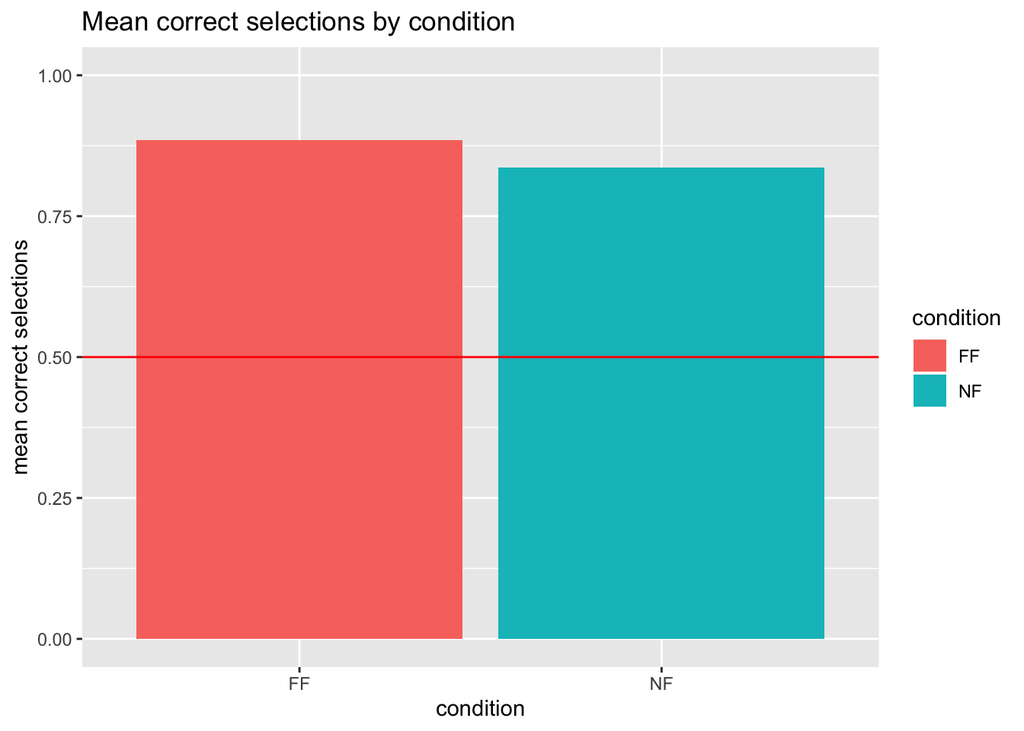

```r
ggplot(overall_means, aes(x = condition, y = mean_correct, fill = condition)) +
  ggtitle("Mean correct selections by condition") +
   geom_bar(stat = "identity") +
  ylab("mean correct selections") +
  ylim(0,1) +
  geom_hline(yintercept = .5, color = "red")
```

1. Do children get better at the NF trials as they get older? The code below makes a new subject means data frame that includes the child age in years. Use this data frame to create a new data frame that has mean performance across children at each age (in years) on only *NF trials*. Plot the data as a bar plot.

```r
subject_means_with_years <- me_data %>%
  group_by(sub_id, age_years, condition) %>%
  summarize(prop_correct = sum(correct)/n())
```

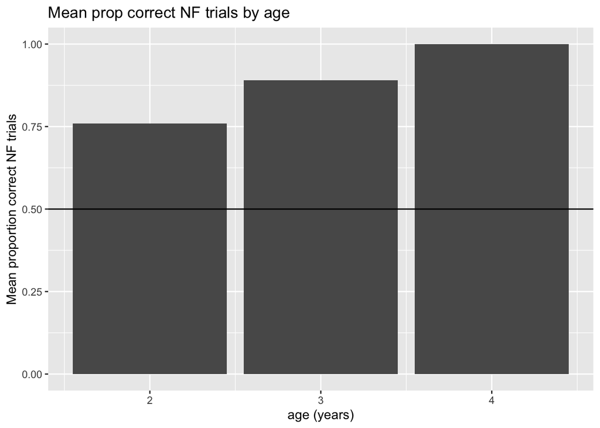

```r
overall_means_by_year <- subject_means_with_years %>%
  filter(condition == "NF") %>%
  group_by(age_years) %>%
  summarize(mean_prop_correct = mean(prop_correct))

ggplot(overall_means_by_year, aes(x = age_years, y = mean_prop_correct)) +
  geom_bar(stat = "identity") +
  ylab("Mean proportion correct NF trials") +
  ggtitle("Mean prop correct NF trials by age") +
  xlab("age (years)") +
  ylim(0,1) +
  geom_hline(yintercept = .5)
```

1. Make a version of the previous plot that shows performance on the NF trials at each age group *for each target object*. Use `facet_wrap()`. You’ll need to create a new data frame like `subject_means_with_years` but one that also includes the variable `target_object`. Call the new data frame `subject_means_with_years_obj.`

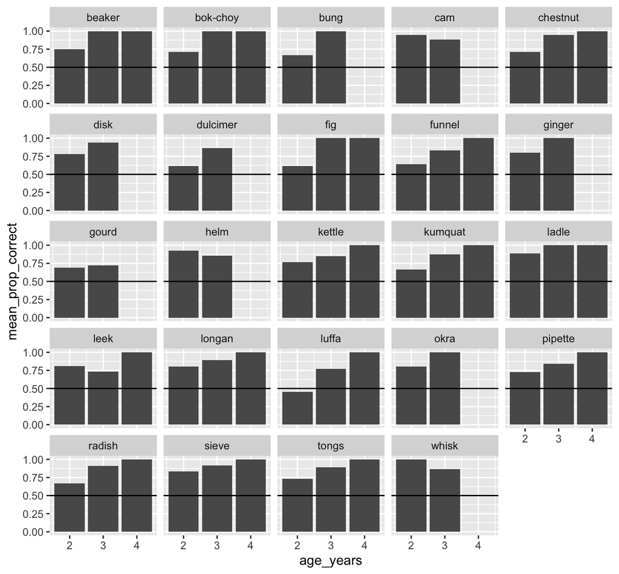

```r
subject_means_with_years_obj <- me_data %>%
  group_by(sub_id, age_years, condition, target_object) %>%
  summarize(prop_correct = sum(correct)/n())

overall_means_by_year_obj <- subject_means_with_years_obj %>%
  filter(condition == "NF") %>%
  group_by(age_years, target_object) %>%
  summarize(mean_prop_correct = mean(prop_correct))

ggplot(overall_means_by_year_obj, aes(x = age_years, y = mean_prop_correct)) +
  geom_bar(stat = "identity") +
  ylim(0,1) +
  facet_wrap(~target_object) +
  geom_hline(yintercept = .5)
```

1. Using `me_data`, make a new variable called `scaled_vocabulary_score` that ranges from 0 to 1, rather than 0 to 100.

```r
me_data <- me_data %>%
  mutate(scaled_vocabulary_score = vocabulary_score/100)
```

1. Use `me_data` to look at the distribution of children’s `vocabulary_score` (use `geom_histogram`). To do this, you’ll need a data frame with only **one** row per child.

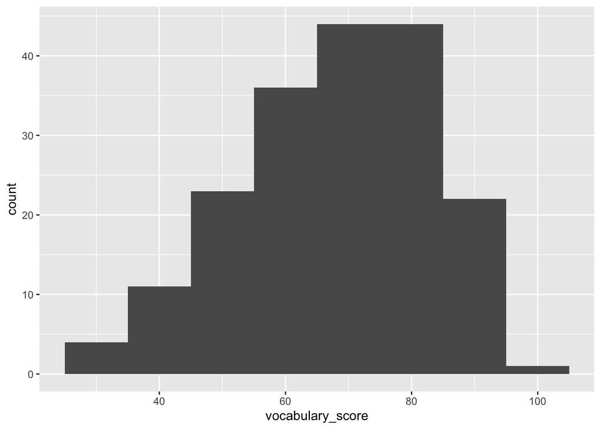

```r
me_data %>%
  distinct(sub_id, .keep_all = TRUE) %>%
  ggplot(aes(x = vocabulary_score)) +
  geom_histogram(binwidth = 10)
```

1. Do older children have higher vocabularies? Recreate the plot below:

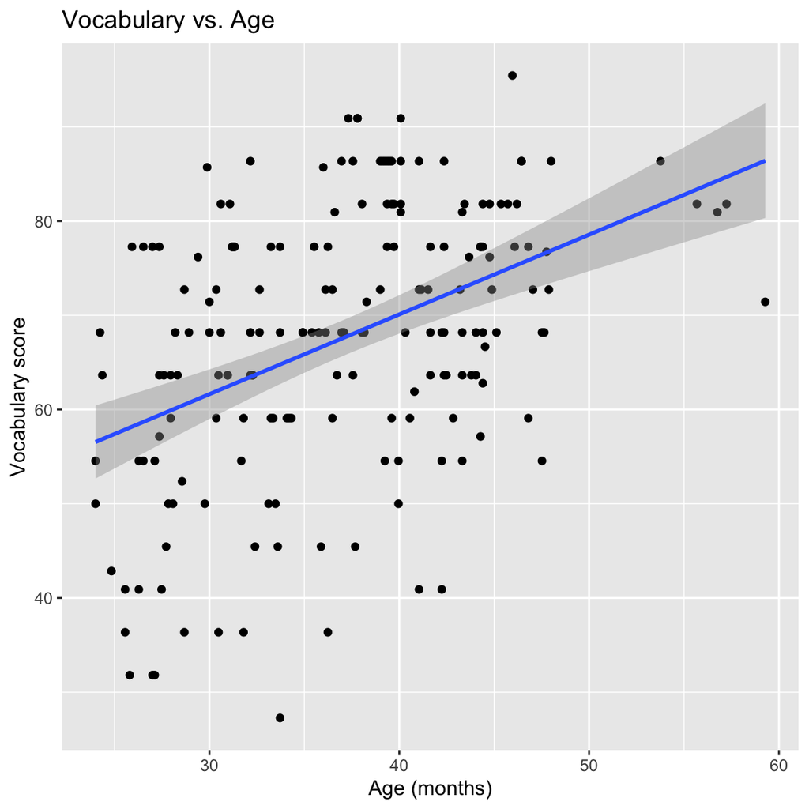

```r
me_data %>%
  distinct(sub_id, .keep_all = TRUE) %>%
  ggplot(aes(x = age_months, y = vocabulary_score)) +
  geom_point() +
  geom_smooth(method = "lm") +
  xlab("Age (months)") +
  ylab("Vocabulary score") +
  ggtitle("Vocabulary vs. Age")
```

1. The goal of the following plot is to show the distributions of vocabulary scores for children at different ages. Modify the code below to make it more effective at communicating this message.

There are a number of things you could do to make this plot better. Here’s one thing:

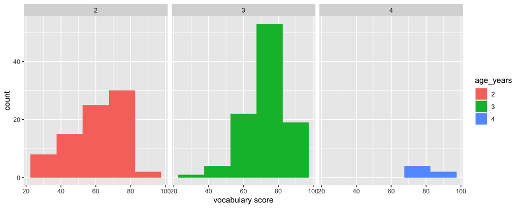

```r
data_by_subject <- me_data %>%
  distinct(sub_id, .keep_all = TRUE) %>%
  mutate(age_years = as_factor(age_years)) # as_factor() changes age_years from a numeric variable to a discrete variable

ggplot(data_by_subject,
       aes(x = vocabulary_score,
           fill = age_years)) +
  scale_fill_discrete() +
  facet_grid(~age_years) +
  xlab("vocabulary score") +
  geom_histogram(binwidth = 15)
```